#### Analyzing the Training Set of Japanese Active Population

After splitting the Japanese Active Population data set into the first 80% training and the latter 20% for testing, I plot the training set with its ACF and PACF.  
The training set exibits seasonality and a trend that grows first but latter falls. In a given year, the population tends to peak between April to July, dips a little around Augest. It rises again between September and October. It gradually falls from November to Feburary, but start rising in March.

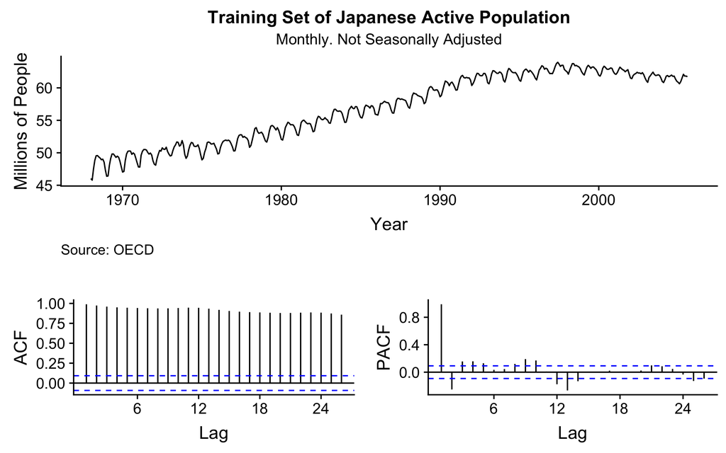

[figure not shown]

The training set series doesn’t pass the ADF stationarity test or the Box-Ljung Test of independence up to 24 lags. We might need to take its differences.

The training set’s ACF decays very slowly. But its PACF drops around the 95% confidence interval after lag 2, suggesting an AR2 process. Since the cut isn’t clear, I will try out various ARMA models.

#### Models

##### Model using 5th Polynomial Trend with Season

AIC= 365.3587 SIC= 439.405  
This model’s training set residuals pass the ADF stationarity test at 5% critical value, but not the Box-Ljung test of independence up to 24 lags.  
Its residuals from the training set have a mean around 0. But the ACF and the PACF suggests at least some AR effcts, probably an order of 2.

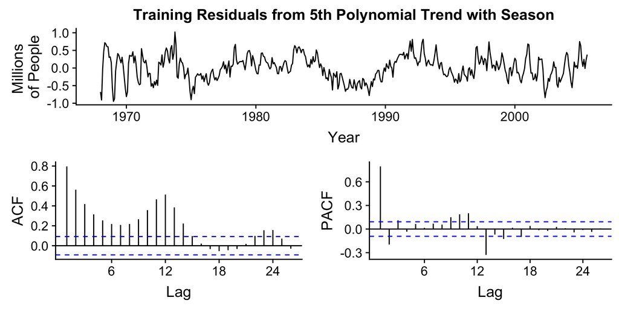

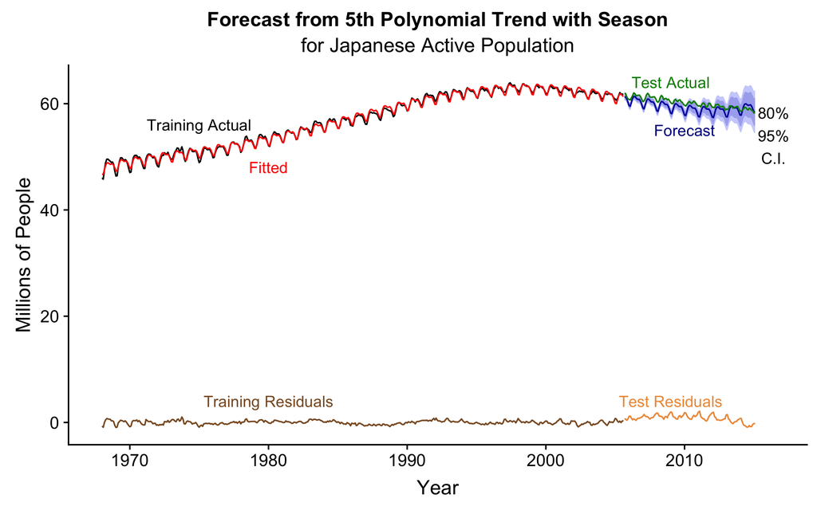

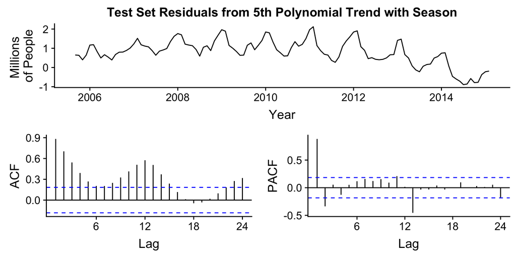

The test set residuals pass the ADF stationarity test at 5% critical value, but not the Box-Ljung test of independence up to 24 lags.

##### Model using ARIMA(0,1,2)(1,1,1)[12]

The auto.arima() function run through more than 20 models to find the one with the lowest AIC. And we get ARIMA(0,1,2)(1,1,1)[12], AIC= -205.5893 SIC= -185.1668.

```
 ARIMA(2,1,2)(1,1,1)[12]                    : -163.8647
 ARIMA(0,1,0)(0,1,0)[12]                    : -27.69069
 ARIMA(1,1,0)(1,1,0)[12]                    : -70.55166
 ARIMA(0,1,1)(0,1,1)[12]                    : -104.6206
 ARIMA(2,1,2)(0,1,1)[12]                    : -147.0154
 ARIMA(2,1,2)(2,1,1)[12]                    : -148.3088
 ARIMA(2,1,2)(1,1,0)[12]                    : -111.5066
 ARIMA(2,1,2)(1,1,2)[12]                    : -163.7104
 ARIMA(2,1,2)(0,1,0)[12]                    : -70.25176
 ARIMA(2,1,2)(2,1,2)[12]                    : -150.5699
 ARIMA(1,1,2)(1,1,1)[12]                    : -168.2072
 ARIMA(1,1,1)(1,1,1)[12]                    : -154.2418
 ARIMA(1,1,3)(1,1,1)[12]                    : -168.629
 ARIMA(0,1,2)(1,1,1)[12]                    : -170.8995
 ARIMA(0,1,2)(0,1,1)[12]                    : -149.5186
 ARIMA(0,1,2)(2,1,1)[12]                    : -161.4623
 ARIMA(0,1,2)(1,1,0)[12]                    : -116.4344
 ARIMA(0,1,2)(1,1,2)[12]                    : -170.3252
 ARIMA(0,1,2)(0,1,0)[12]                    : -73.92797
 ARIMA(0,1,2)(2,1,2)[12]                    : -161.1532
 ARIMA(0,1,1)(1,1,1)[12]                    : -131.9326
 ARIMA(0,1,3)(1,1,1)[12]                    : -168.9075

 Now re-fitting the best model(s) without approximations...

 ARIMA(0,1,2)(1,1,1)[12]                    : -205.5893

 Best model: ARIMA(0,1,2)(1,1,1)[12]
```

This model’s training set residuals pass both the ADF stationarity test at the 5% critical value and the Box-Ljung test of independence up to 24 lags. The residual series resemble a white noise process. Neither the ACF or the PACF go beyond the 95% confidence interval, suggesting no ARMA effects.

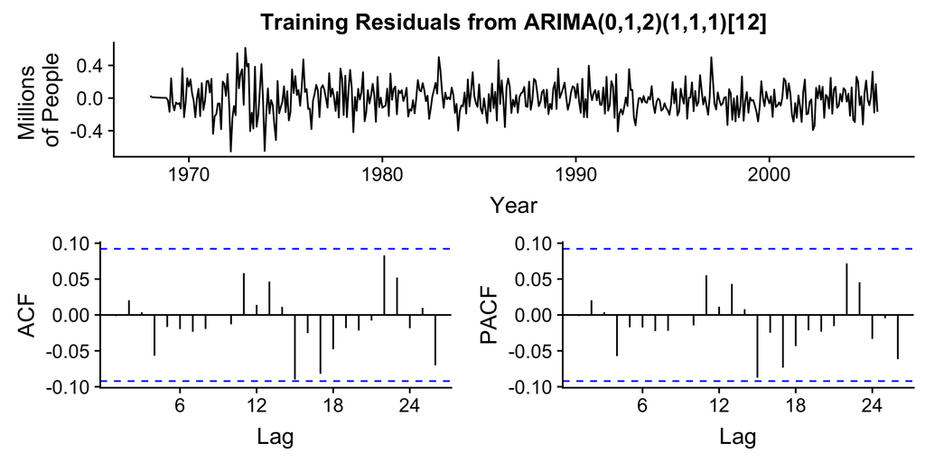

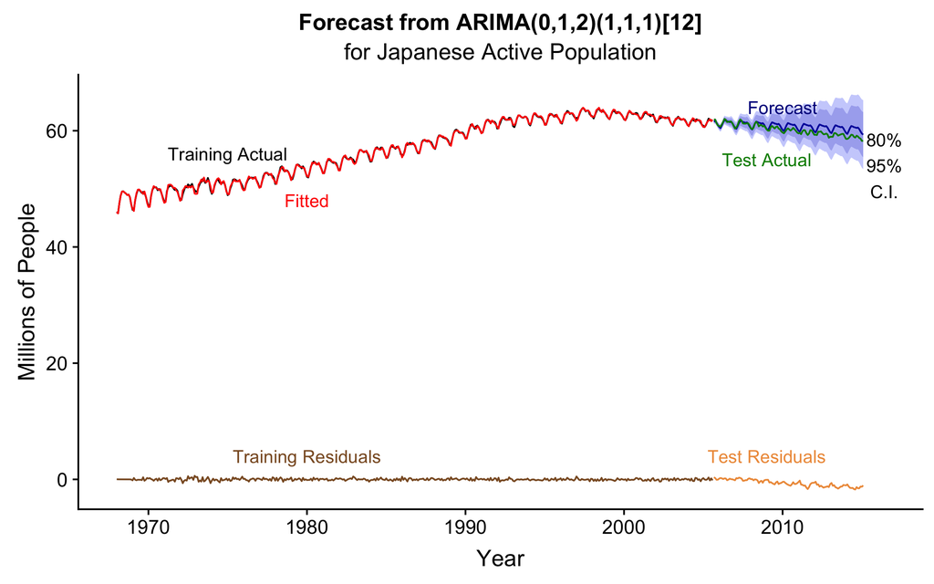

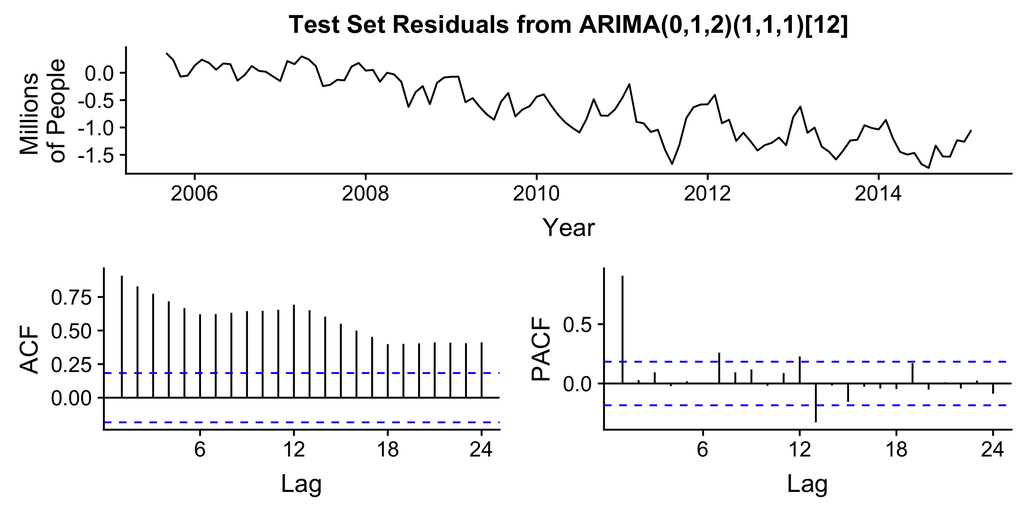

The test set residuals pass the ADF stationarity test at 5% critical value, but not the Box-Ljung test of independence up to 24 lags.

### Comparing Forecasting Performances

```
Error Measures for 5th Polynomial Trend with Season
                       ME      RMSE       MAE          MPE     MAPE      MASE      ACF1 Theil's U
Training set 1.577274e-17 0.3483305 0.2826810 -0.004564249 0.506062 0.5774088 0.7964946        NA
Test set     7.960438e-01 1.0304044 0.9148707  1.317876875 1.519403 1.8687299 0.8821920  3.478338

Error Measures for ARIMA(0,1,2)(1,1,1)[12]
                       ME      RMSE       MAE         MPE      MAPE      MASE         ACF1 Theil's U
Training set -0.007967135 0.1852938 0.1442377 -0.01218334 0.2582492 0.2946224 -0.001664239        NA
Test set     -0.633904018 0.8524901 0.6885788 -1.06620687 1.1552499 1.4065024  0.908165399  2.917644
```

Next, I can redo the forecast with better models recommended by the group.